# Exploratory Data Analysis (EDA)

*(i) Finding the top five most delayed flights. Report the flight date, origin, destination, carrier, flight number, and arrival delay*.

```r
not_canceled= flights %>%filter(!is.na(dep_delay), !is.na(arr_delay))
top_five_delayed_flights= not_canceled %>% arrange(desc(arr_delay)) %>%
  head(5) %>%select(year, month, day, origin, dest, carrier, flight, arr_delay)
top_five_delayed_flights
## # A tibble: 5 × 8
##    year month   day origin dest  carrier flight arr_delay
##   <int> <int> <int> <chr>  <chr> <chr>    <int>     <dbl>
## 1  2013     1     9 JFK    HNL   HA          51      1272
## 2  2013     6    15 JFK    CMH   MQ        3535      1127
## 3  2013     1    10 EWR    ORD   MQ        3695      1109
## 4  2013     9    20 JFK    SFO   AA         177      1007
## 5  2013     7    22 JFK    CVG   MQ        3075       989
```

*(ii) Finding the flights traveled the longest by distance*.

```r
# Arranging the flights data by descending order with distance
longest_flights = not_canceled %>%arrange(desc(distance))

# Longest flight's carrier,origin airport, & destination airport
longest_flights %>%select(carrier, origin, dest)
## # A tibble: 327,346 × 3
##    carrier origin dest
##    <chr>   <chr>  <chr>
##  1 HA      JFK    HNL
##  2 HA      JFK    HNL
##  3 HA      JFK    HNL
##  4 HA      JFK    HNL
##  5 HA      JFK    HNL
##  6 HA      JFK    HNL
##  7 HA      JFK    HNL
##  8 HA      JFK    HNL
##  9 HA      JFK    HNL
## 10 HA      JFK    HNL
## # ℹ 327,336 more rows

#additonal flights if one is interested to know beyond the longest
#head(unique(longest_flights$carrier))  #carrier in decreasing order
#head(unique(longest_flights$origin))   #the origin airport in decreasing order
#head(unique(longest_flights$dest))   #the origin airport in decreasing order
```

*Question* :What are the carrier, the origin airport, and the destination airport of these flights?

**c) Selection : Pick variables by their names - `select()`**

Listing at least three ways to select `dep_time`, `dep_delay`, `arr_time`, and `arr_delay` from **non-canceled** flights.

1. Using the column names:

```r
not_canceled %>% select(dep_time, dep_delay, arr_time, arr_delay)
## # A tibble: 327,346 × 4
##    dep_time dep_delay arr_time arr_delay
##       <int>     <dbl>    <int>     <dbl>
##  1      517         2      830        11
##  2      533         4      850        20
##  3      542         2      923        33
##  4      544        -1     1004       -18
##  5      554        -6      812       -25
##  6      554        -4      740        12
##  7      555        -5      913        19
##  8      557        -3      709       -14
##  9      557        -3      838        -8
## 10      558        -2      753         8
## # ℹ 327,336 more rows
```

2. Using the starts_with() function to select columns “dep” or “arr”

```r
s=not_canceled %>%select(starts_with(c("dep", "arr")))
head(s)
## # A tibble: 6 × 4
##   dep_time dep_delay arr_time arr_delay
##      <int>     <dbl>    <int>     <dbl>
## 1      517         2      830        11
## 2      533         4      850        20
## 3      542         2      923        33
## 4      544        -1     1004       -18
## 5      554        -6      812       -25
## 6      554        -4      740        12

#or following code also works
not_canceled %>%select(starts_with("dep"), starts_with("arr"))
## # A tibble: 327,346 × 4
##    dep_time dep_delay arr_time arr_delay
##       <int>     <dbl>    <int>     <dbl>
##  1      517         2      830        11
##  2      533         4      850        20
##  3      542         2      923        33
##  4      544        -1     1004       -18
##  5      554        -6      812       -25
##  6      554        -4      740        12
##  7      555        -5      913        19
##  8      557        -3      709       -14
##  9      557        -3      838        -8
## 10      558        -2      753         8
## # ℹ 327,336 more rows
```

3. Using the contains() function to select columns having “time” or “delay”:

```r
not_canceled %>%
select(contains("time"), contains("delay"))
## # A tibble: 327,346 × 8
##    dep_time sched_dep_time arr_time sched_arr_time air_time time_hour
##       <int>          <int>    <int>          <int>    <dbl> <dttm>
##  1      517            515      830            819      227 2013-01-01 05:00:00
##  2      533            529      850            830      227 2013-01-01 05:00:00
##  3      542            540      923            850      160 2013-01-01 05:00:00
##  4      544            545     1004           1022      183 2013-01-01 05:00:00
##  5      554            600      812            837      116 2013-01-01 06:00:00
##  6      554            558      740            728      150 2013-01-01 05:00:00
##  7      555            600      913            854      158 2013-01-01 06:00:00
##  8      557            600      709            723       53 2013-01-01 06:00:00
##  9      557            600      838            846      140 2013-01-01 06:00:00
## 10      558            600      753            745      138 2013-01-01 06:00:00
## # ℹ 327,336 more rows
## # ℹ 2 more variables: dep_delay <dbl>, arr_delay <dbl>
```

**d) Create new variables with functions of existing variables - `mutate()`**

Example code creating delay ratio of arrival to departure.

```r
not_canceled %>%
mutate(delay_ratio = arr_delay/ dep_delay)
## # A tibble: 327,346 × 20
##     year month   day dep_time sched_dep_time dep_delay arr_time sched_arr_time
##    <int> <int> <int>    <int>          <int>     <dbl>    <int>          <int>
##  1  2013     1     1      517            515         2      830            819
##  2  2013     1     1      533            529         4      850            830
##  3  2013     1     1      542            540         2      923            850
##  4  2013     1     1      544            545        -1     1004           1022
##  5  2013     1     1      554            600        -6      812            837
##  6  2013     1     1      554            558        -4      740            728
##  7  2013     1     1      555            600        -5      913            854
##  8  2013     1     1      557            600        -3      709            723
##  9  2013     1     1      557            600        -3      838            846
## 10  2013     1     1      558            600        -2      753            745
## # ℹ 327,336 more rows
## # ℹ 12 more variables: arr_delay <dbl>, carrier <chr>, flight <int>,
## #   tailnum <chr>, origin <chr>, dest <chr>, air_time <dbl>, distance <dbl>,
## #   hour <dbl>, minute <dbl>, time_hour <dttm>, delay_ratio <dbl>
```

*(i) Creating a new variable `flight_time` which equals `arr_time` - `dep_time`* We also make a scatter plot to compare `flight_time` with `air_time`.

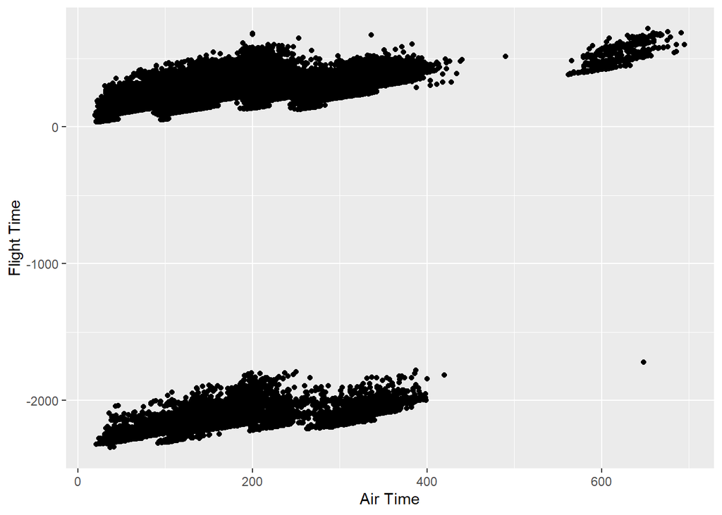

```r
not_canceled %>%
mutate(flight_time = arr_time - dep_time) %>%
ggplot(aes(x = air_time, y = flight_time)) +
geom_point()+
xlab("Air Time") +
ylab("Flight Time")
```

*Question* What do you expect to see? What do you see? Why are there negative values in `flight_time`?

*Answer* I was expecting a scatter plot showing relationship between flight time and air time variables. I saw that there are considerable number of negative values. The negative values of flight time could be because of three main reasons: difference in time zone due to daylight saving time, human error in recording, flight taking off one day and landing next day but day change is not taken into account.

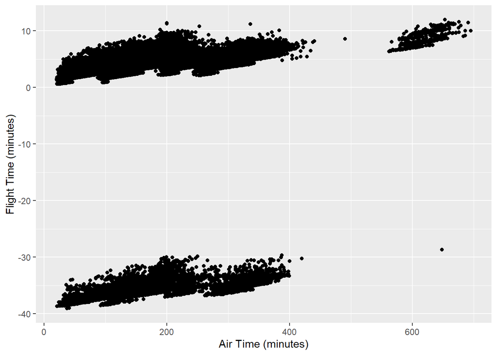

```r
library(lubridate)  #deals well with date and time

not_canceled_fixed = not_canceled %>%mutate(dep_time = hms::as_hms(dep_time),
    arr_time = hms::as_hms(arr_time),flight_time = difftime(arr_time, dep_time, units = "mins"))

ggplot(not_canceled_fixed, aes(x = air_time, y = flight_time)) +
  geom_point() + xlab("Air Time (minutes)")+ ylab("Flight Time (minutes)")
## Don't know how to automatically pick scale for object of type <difftime>.
## Defaulting to continuous.
```

**e) More on date and time**

We note and wonder why our scatter plot didn’t have a clear linear relationship. The reasons were due to the time zone differences as well as the daylight saving time (DST). Now we modify our R code to solve these issues.

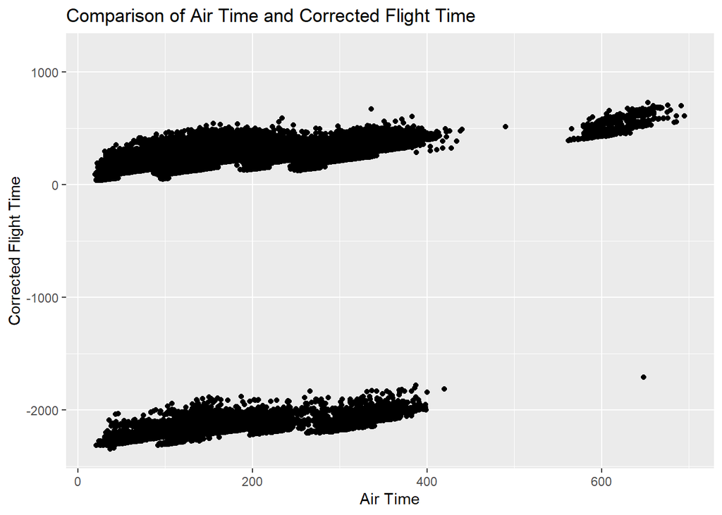

```r
#?airports
#airports %>% glimpse()  #user can run this code to see airports. We save some space by commenting it

# joining `flights` and `airports` using destination airport FAA code as the _key_.
flights_with_airports= left_join(flights, airports, by = c("dest" = "faa"))

#create d_s_t (day saving time) variable
flights_with_airports= flights_with_airports %>%
  mutate(dst = ifelse(lon >= -75 & lon <= -67, "eastern",
  ifelse(lon >= -160 & lon <= -154, "hawaii-aleutian",
  ifelse(lon >= -157 & lon <= -155, "hawaii-aleutian", "other"))))

# create corrected_arr_time variable
flights_with_airports = flights_with_airports %>%
   mutate(corrected_arr_time = arr_time + ifelse(dst == "eastern", 4,
   ifelse(dst == "hawaii-aleutian", 10, 0)))

# making the scatter plot
ggplot(flights_with_airports, aes(x = air_time, y = corrected_arr_time - dep_time)) +
  geom_point() + xlab("Air Time") +  ylab("Corrected Flight Time") +
  ggtitle("Comparison of Air Time and Corrected Flight Time")
## Warning: Removed 16967 rows containing missing values (`geom_point()`).
```

***Summary Statistics: Calculating group-wise summaries - combine `summarise()` and `group_by()`**

Example code : summarizing mean arrival delay:

```r
not_canceled %>%
group_by(carrier) %>%
summarise(mean_arr_delay = mean(arr_delay, na.rm = TRUE))
## # A tibble: 16 × 2
##    carrier mean_arr_delay
##    <chr>            <dbl>
##  1 9E               7.38
##  2 AA               0.364
##  3 AS              -9.93
##  4 B6               9.46
##  5 DL               1.64
##  6 EV              15.8
##  7 F9              21.9
##  8 FL              20.1
##  9 HA              -6.92
## 10 MQ              10.8
## 11 OO              11.9
## 12 UA               3.56
## 13 US               2.13
## 14 VX               1.76
## 15 WN               9.65
## 16 YV              15.6
```

**a) Daily flight cancellation rate**

```r
# Filter out cancelled flights
flights_not_cancelled = flights %>%
filter(!is.na(dep_delay), !is.na(arr_delay))

# Group the flights by date
grouped_flights = flights_not_cancelled %>%
group_by(date = as.Date(as.POSIXct(time_hour, format = "%Y-%m-%d")))

# Calculate the proportion of flights that were cancelled for each day
daily_cancellation_rate = grouped_flights %>%
  summarise(cancelled = sum(is.na(dep_delay)),
  total_flights = n(),
  cancellation_rate = cancelled / total_flights)
daily_cancellation_rate
## # A tibble: 366 × 4
##    date       cancelled total_flights cancellation_rate
##    <date>         <int>         <int>             <dbl>
##  1 2013-01-01         0           701                 0
##  2 2013-01-02         0           915                 0
##  3 2013-01-03         0           901                 0
##  4 2013-01-04         0           909                 0
##  5 2013-01-05         0           765                 0
##  6 2013-01-06         0           782                 0
##  7 2013-01-07         0           928                 0
##  8 2013-01-08         0           896                 0
##  9 2013-01-09         0           896                 0
## 10 2013-01-10         0           921                 0
## # ℹ 356 more rows
```

*b) Is there a pattern in studying the number of canceled flights per day?* We make a scatter plot of the proportion of canceled flights per day (x-axis) vs average delay per day (y-axis). We then use point size to represent the number of originally scheduled flights on each day. Now we add a smoothed fitted line to your scatter plot. Now we see whether the proportion of canceled flights relates to the average delay?

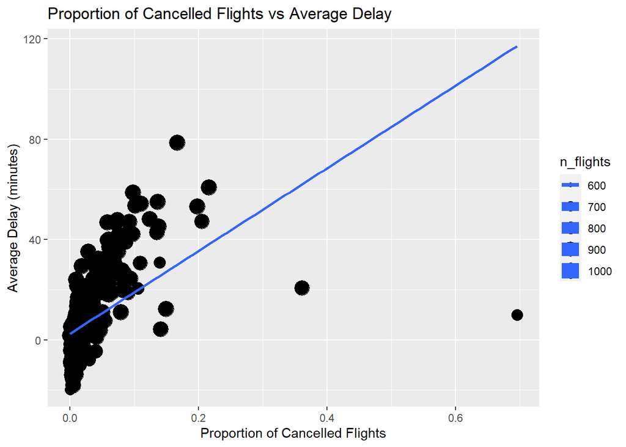

```r
library(tidyverse)

flights %>%
  mutate(date = as.Date(time_hour)) %>%
  group_by(month = format(date, "%m"), day = format(date, "%d")) %>%
  summarize(prop_cancelled = sum(is.na(arr_delay))/n(),
  avg_delay = mean(arr_delay, na.rm = TRUE),
  n_flights = n()) %>%
  ggplot(aes(prop_cancelled, avg_delay, size = n_flights)) +
  geom_point() +
  geom_smooth(method = "lm", se = FALSE) +
  ggtitle("Proportion of Cancelled Flights vs Average Delay") +
  xlab("Proportion of Cancelled Flights") +
  ylab("Average Delay (minutes)")
## `summarise()` has grouped output by 'month'. You can override using the
## `.groups` argument.
## Warning: Using `size` aesthetic for lines was deprecated in ggplot2 3.4.0.
## ℹ Please use `linewidth` instead.
## This warning is displayed once every 8 hours.
## Call `lifecycle::last_lifecycle_warnings()` to see where this warning was
## generated.
## `geom_smooth()` using formula = 'y ~ x'
## Warning: The following aesthetics were dropped during statistical transformation: size
## ℹ This can happen when ggplot fails to infer the correct grouping structure in
##   the data.
## ℹ Did you forget to specify a `group` aesthetic or to convert a numerical
##   variable into a factor?
```

*i) worst days for flight cancellation*

*Question* Which two days had the highest flight cancellation rates?

*Answer* Two days that had the highest flight cancellation rate are 2013-02-09, 2013-02-08. The following code prints out the desired results. **ANSWER**

```r
flights %>%
  mutate(date = as.Date(paste0(year, "-", month, "-", day))) %>%
  group_by(date) %>%
  summarise(cancelled_count = sum(is.na(dep_time)),
  total_count = n(),
  cancellation_rate = cancelled_count / total_count) %>%
  arrange(desc(cancellation_rate)) %>%
  head(2)
## # A tibble: 2 × 4
##   date       cancelled_count total_count cancellation_rate
##   <date>               <int>       <int>             <dbl>
## 1 2013-02-09             393         684             0.575
## 2 2013-02-08             472         930             0.508
```

*ii) We now remove the two days with the highest flight cancellation rates and re-draw our scatter plot*.

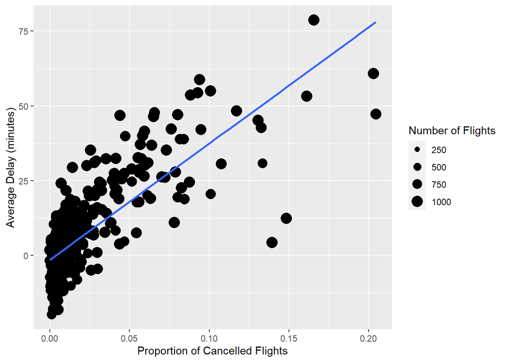

```r
library(tidyverse)
library(lubridate)

flights_data=nycflights13::flights


daily_flights = flights_data %>% # firstly, Group by date and
  group_by(date = as.Date(time_hour)) %>%  # calculate the number of flights,
  summarize(flights = n(),
  cancelled = sum(is.na(dep_time)), #calculate the number of cancelled flights, the average delay
  avg_delay = mean(arr_delay, na.rm = TRUE))


highest_cancellation_days = daily_flights %>% # Filtering two days having the highest cancellation rates
  arrange(desc(cancelled/flights)) %>%
  head(2) %>%
  pull(date)

daily_flights_no_outliers = daily_flights %>%
  filter(!date %in% highest_cancellation_days)


ggplot(daily_flights_no_outliers, # Plotting the proportion of cancelled(flights vs average delay)
       aes(x = cancelled/flights, y = avg_delay)) +
  geom_point(aes(size = flights)) +
  geom_smooth(method = "lm", se = FALSE) +
  scale_size(range = c(0, 5)) +
  labs(x = "Proportion of Cancelled Flights", y = "Average Delay (minutes)", size = "Number of Flights")
## `geom_smooth()` using formula = 'y ~ x'
```